# Basic MCMC

James D. Wilson

April 29, 2017

## Gibbs Sampler Example

Here, are goal is to simulate bivariate draws of ($\theta_1, \theta_2$) from the multivariate normal distribution, where:

$$\begin{pmatrix} \theta_1 \\ \theta_2 \end{pmatrix} \mid y \sim N\left(\begin{pmatrix}y_1 \\ y_2 \end{pmatrix}, \begin{pmatrix} 1 & \rho \\ \rho & 1\end{pmatrix} \right)$$
We will use a Gibbs sampler to do this and compare with directly drawing from this distribution as an example.

The Gibbs sampler proceeds in two alternating steps. First, take a random first guess $\theta^0$. Then, for $t > 0$

1. Simulate $\theta_1^t \sim N(y_1 + \rho(\theta_2 - y_2), 1 - \rho^2)$
2. Simulate $\theta_2^t \sim N(y_2 + \rho(\theta_1 - y_1), 1 - \rho^2)$

For the sake of an example, set $(y_1, y_2) = (1, 1)$ and set $\rho = 0.8$ We implement this Gibbs Sampler below.

```r
gibbs.normal <- function(y1, y2, rho, theta0, N, burnin){
  #y1 and y2 - observed data
  #rho - the correlation between theta1 and theta2
  #theta0 - initial guess (two dimensional vector)
  #N - total number of simulations
  #burnin - how many of the initial simulations should be tossed?
  theta1 <- rep(0, N+burnin)
  theta2 <- rep(0, N+burnin)
  theta1[1] <- theta0[1]
  theta2[1] <- theta0[2]
  for(s in 2:(N+burnin)){
    theta1[s] <- rnorm(1, mean = y1 + rho*(theta2[s-1] - y2),
                       sd = sqrt(1 - rho^2))
    theta2[s] <- rnorm(1, mean = y2 + rho*(theta1[s] - y1),
                       sd = sqrt(1 - rho^2))
  }
  result <- data.frame(theta1 = theta1[(burnin+1):(N+burnin)],
                       theta2 = theta2[(burnin+1):(N+burnin)])
  return(result)
}
```

```r
set.seed(123)
samples <- gibbs.normal(y1 = 1, y2 = 1, rho = 0.8, theta0 = c(1, 5), N = 10000, burnin = 0)
```

**Plot the samples values of $\theta_1$ and $\theta_2$ to inspect convergence**

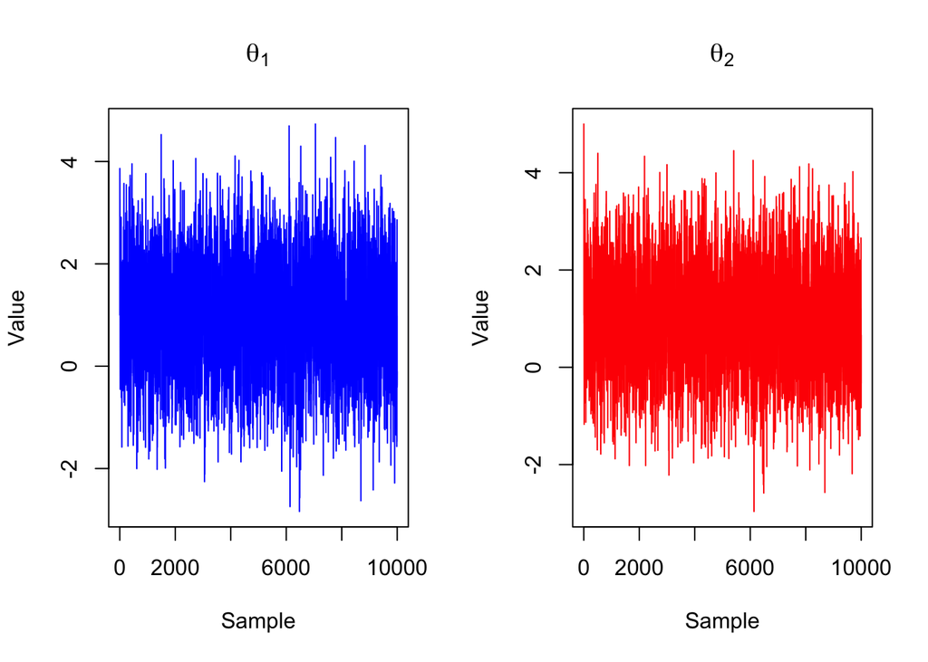

```r
par(mfrow = c(1, 2))
plot(y = samples$theta1, x = 1:10000, xlab = "Sample", ylab = "Value", type = "l", col = "blue",
     main = expression(theta[1]))
plot(y = samples$theta2, x = 1:10000, xlab = "Sample", ylab = "Value", type = "l", col = "red",
     main = expression(theta[2]))
```

**Note**: inspection suggests that the chain is stationary. We’ll come back later to determine whether or not this is true. For now, we will keep everything after the first 100 samples and plot them.

Also, we will simulate from the true multivariate normal to compare the two distributions.

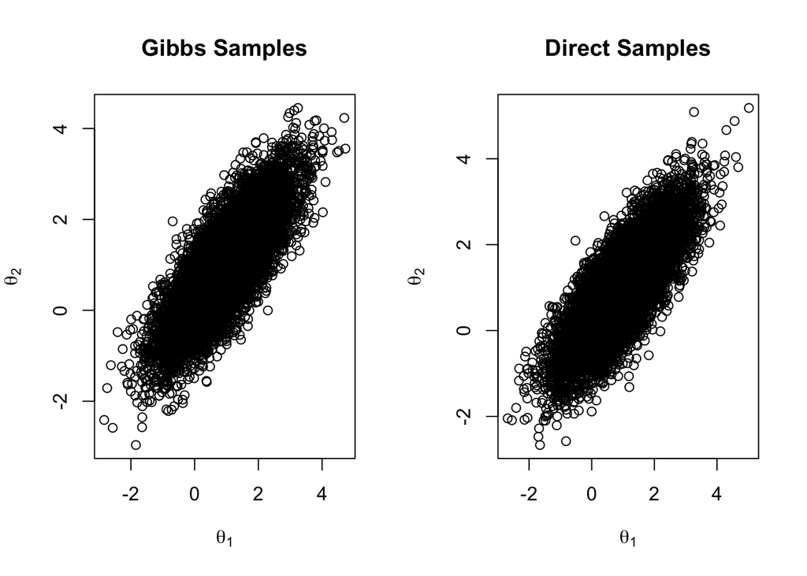

```r
install.packages("MASS", repos = "https://cloud.r-project.org")
library(MASS, quietly = TRUE)

#simulate from Multivariate Normal distribution directly for comparison
true.values <- mvrnorm(n = 10000, mu = c(1, 1), Sigma = cbind(c(1, 0.8), c(0.8, 1)))

par(mfrow = c(1,2))
plot(y = samples$theta2[100:10000], x = samples$theta1[100:10000],
     xlab = expression(theta[1]), ylab = expression(theta[2]),
     main = "Gibbs Samples")
plot(y = true.values[, 1], x = true.values[, 2], xlab = expression(theta[1]),
     ylab = expression(theta[2]), main = "Direct Samples")
```

## Metropolis Algorithm Example

Continuing with the above example, we now try the Metropolis algorithm using the proposal distribution $N(\theta^{t-1}, I)$ for the observed possible simulation $\theta^*$.

```r
metropolis.normal <- function(y1, y2, rho, theta0, N, burnin){
  #theta0 - an initial guess (must be 2-dimensional vector)
  #N - number of simulations
  #burnin - number of burnin samples
  theta1 <- rep(0, N+burnin)
  theta2 <- rep(0, N+burnin)
  theta1[1] <- theta0[1]
  theta2[1] <- theta0[2]
  Sigma <- cbind(c(1, rho), c(rho, 1))
  #function to calculate the ratio using unnormalized part of the density function for a Normal(y, Sigma)
  ratio <- function(theta.new, theta.old){
    numerator <- exp(-.5*t(theta.new - c(y1, y2))%*%solve(Sigma)%*%(theta.new - c(y1, y2)))
    denominator <- exp(-.5*t(theta.old - c(y1, y2))%*%solve(Sigma)%*%(theta.old - c(y1, y2)))
    r <- numerator / denominator
    return(min(r,1))
  }

  for(s in 2:(N + burnin)){
    theta.new <- mvrnorm(n = 1, mu = c(theta1[s-1], theta2[s-1]), Sigma = diag(2))
    theta.old <- c(theta1[s-1], theta2[s-1])
    r <- ratio(theta.new, theta.old)
    U <- runif(1, 0, 1)
    if(U < r){
      theta1[s] <- theta.new[1]
      theta2[s] <- theta.new[2]
    }
    if(U >= r){
      theta1[s] <- theta1[s-1]
      theta2[s] <- theta2[s-1]
    }
  }
  result <- data.frame(theta1 = theta1[(burnin+1):(N+burnin)],
                       theta2 = theta2[(burnin+1):(N+burnin)])
  return(result)
}
```

**Run Metropolis**

```r
sample.Metropolis <- metropolis.normal(y1 = 1, y2 = 1, rho = 0.8,
                                       theta0 = c(1,1), N = 10000,
                                       burnin = 0)
```

**Plot diagnostics and plot these results against the truth**

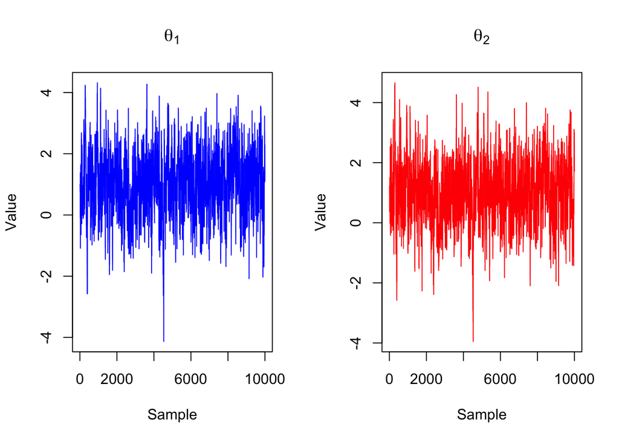

```r
par(mfrow = c(1, 2))
plot(y = sample.Metropolis$theta1, x = 1:10000, xlab = "Sample", ylab = "Value", type = "l", col = "blue",
     main = expression(theta[1]))
plot(y = sample.Metropolis$theta2, x = 1:10000, xlab = "Sample", ylab = "Value", type = "l", col = "red",
     main = expression(theta[2]))
```

Again, it looks fairly stationary past perhaps a burnin of 1000. Let’s look at those values against the truth.

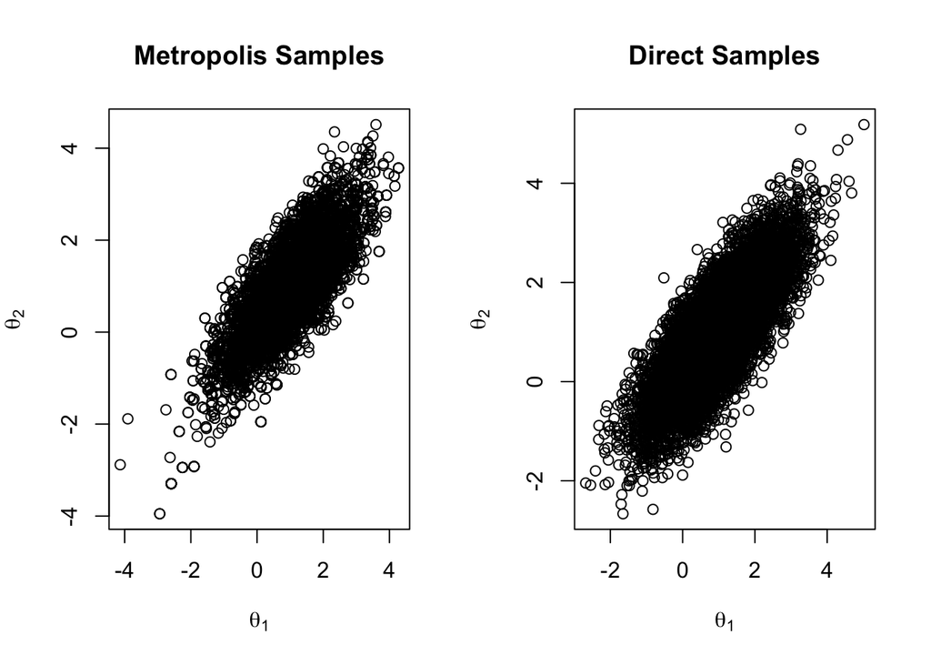

```r
par(mfrow = c(1,2))
plot(y = sample.Metropolis$theta2[1000:10000], x = sample.Metropolis$theta1[1000:10000],
     xlab = expression(theta[1]), ylab = expression(theta[2]),
     main = "Metropolis Samples")
plot(y = true.values[, 1], x = true.values[, 2], xlab = expression(theta[1]),
     ylab = expression(theta[2]), main = "Direct Samples")
```

## Metropolis-Hastings Algorithm Example

Continuing with the above example, we now try the Metropolis-Hastings algorithm using the proposal distribution $N((0.8\theta^{t-1}, I)$ for the observed possible simulation $\theta^*$.

Important point here: we really only need to change our `ratio` function from the `metropolis.normal` function above. We do that in the next code.

**Note**: Try different multipliers of $\theta^{t-1}$ to see major differences in how long it takes M-H to converge.

```r
metropolis.hastings.normal <- function(y1, y2, rho, theta0, N,
                                       burnin){
  #theta0 - an initial guess (must be 2-dimensional vector)
  #N - number of simulations
  #burnin - number of burnin samples
  theta1 <- rep(0, N+burnin)
  theta2 <- rep(0, N+burnin)
  theta1[1] <- theta0[1]
  theta2[1] <- theta0[2]
  Sigma <- cbind(c(1, rho), c(rho, 1))
  #function to calculate the ratio using unnormalized part of the density function for a Normal(y, Sigma)
  ratio <- function(theta.new, theta.old){
    numerator1 <- exp(-.5*t(theta.new - c(y1, y2))%*%solve(Sigma)%*%(theta.new - c(y1, y2)))

    #J(theta.old | theta.new)
    numerator2 <- dnorm(theta.old[1], mean = .8*theta.new[1], sd = 1) *
      dnorm(theta.old[2], mean = .8*theta.new[2], sd = 1)

    denominator1 <- exp(-.5*t(theta.old - c(y1, y2))%*%solve(Sigma)%*%(theta.old - c(y1, y2)))
    #J(theta.new | theta.old)
    denominator2 <- dnorm(theta.new[1], mean = .8*theta.old[1], sd = 1) *
      dnorm(theta.new[2], mean = .8*theta.old[2], sd = 1)

    r <- (numerator1*numerator2) / (denominator1*denominator2)
    return(min(r,1))
  }

  for(s in 2:(N + burnin)){
    theta.new <- mvrnorm(n = 1, mu = .8*c(theta1[s-1], theta2[s-1]), Sigma = diag(2))
    theta.old <- c(theta1[s-1], theta2[s-1])
    r <- ratio(theta.new, theta.old)
    U <- runif(1, 0, 1)
    if(U < r){
      theta1[s] <- theta.new[1]
      theta2[s] <- theta.new[2]
    }
    if(U >= r){
      theta1[s] <- theta1[s-1]
      theta2[s] <- theta2[s-1]
    }
  }
  result <- data.frame(theta1 = theta1[(burnin+1):(N+burnin)],
                       theta2 = theta2[(burnin+1):(N+burnin)])
  return(result)
}
```

**Run Metropolis-Hastings**

```r
sample.Metropolis.Hastings <- metropolis.hastings.normal(y1 = 1,
                                       y2 = 1, rho = 0.8,
                                       theta0 = c(1,1), N = 10000,
                                       burnin = 0)
```

**Plot Diagnostics and Compare against true distribution**

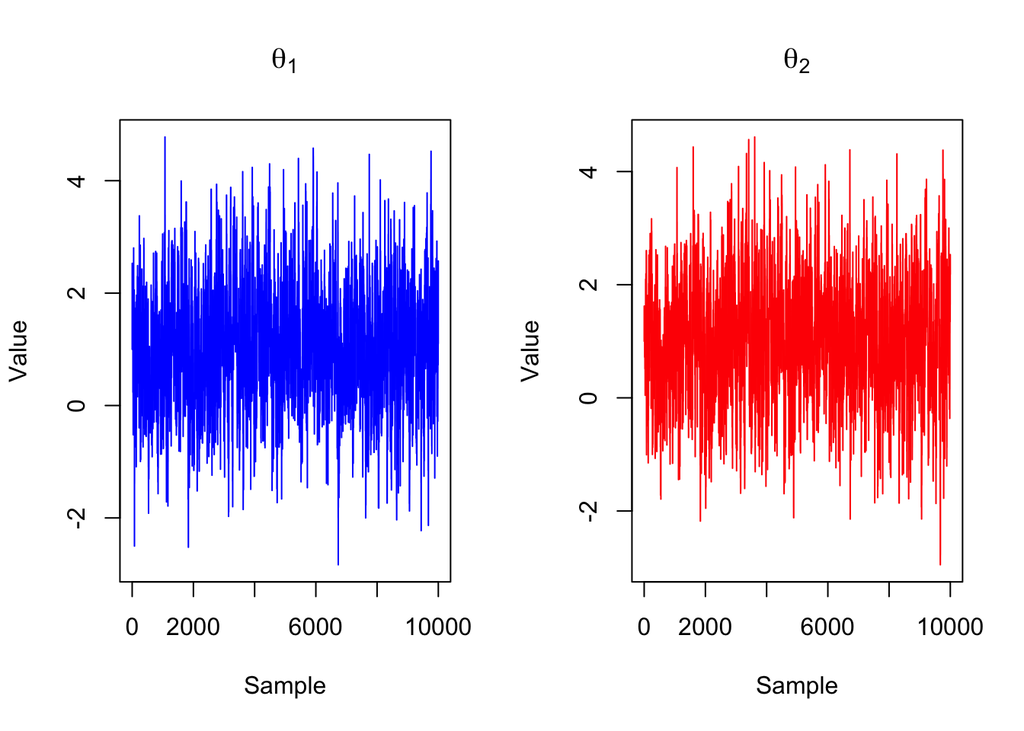

```r
par(mfrow = c(1, 2))
plot(y = sample.Metropolis.Hastings$theta1, x = 1:10000, xlab = "Sample", ylab = "Value", type = "l", col = "blue",
     main = expression(theta[1]))
plot(y = sample.Metropolis.Hastings$theta2, x = 1:10000, xlab = "Sample", ylab = "Value", type = "l", col = "red",
     main = expression(theta[2]))
```

Again, it looks fairly stationary past perhaps a burnin of 1000. Let’s look at those values against the truth.

[figure not shown]

```r
par(mfrow = c(1,2))
plot(y = sample.Metropolis$theta2[1000:10000], x = sample.Metropolis$theta1[1000:10000],
     xlab = expression(theta[1]), ylab = expression(theta[2]),
     main = "Metropolis-Hastings Samples")
plot(y = true.values[, 1], x = true.values[, 2], xlab = expression(theta[1]),
     ylab = expression(theta[2]), main = "Direct Samples")
```